# TCN 2018 - impact of contact intervention on valuing diversity

# Data preparation

## Load required packages

**Source**

```r
pacman::p_load_gh("lukaswallrich/timesaveR")
pacman::p_load(tidyverse, magrittr, lme4, lmerTest, ordinal, ungeviz)
```

## Load & filter data

**Source**

```r
#Please contact Lukas Wallrich (l.wallrich@gold.ac.uk | lukas.wallrich@gmail.com) to access the data.
AllData = readxl::read_excel('Matched 2018 Summer impact responses 081118.xlsx')
```

## Sample desc

**Source**

```r
AllData$`Survey type1`[AllData$`Survey type1`!="FALSE"] %>%
  table() %>% addmargins()
```

**Output**

```
## .
##    E    S  Sum
## 1124 1200 2324
```

**Source**

```r
AllData$`Survey type2`[AllData$`Survey type2`!="FALSE"] %>%
  table() %>% addmargins()
```

**Output**

```
## .
##    E    S  Sum
##  914  717 1631
```

**Source**

```r
AllData$BothWaves %>% table()
```

**Output**

```
## .
## FALSE  TRUE
##  2593   705
```

**Source**

```r
AllDataBoth <- AllData %>%
  filter(BothWaves) %>%
  mutate(Ethn_type = case_when(
    str_detect(Ethnicity, "White|Irish") & !str_detect(Ethnicity, c("Black|Arab|Asian|Pakistani|Bangladeshi|Indian|Chinese|Mixed")) ~ "White",
    !str_detect(Ethnicity, "White|Irish|Mixed") & str_detect(Ethnicity, c("Black|Arab|Asian|Pakistani|Bangladeshi|Indian|Chinese|Any other")) ~ "ME",
    str_detect(Ethnicity, "White|Irish|Mixed") & str_detect(Ethnicity, c("Black|Arab|Asian|Pakistani|Bangladeshi|Indian|Mixed|Chinese")) ~ "Mixed",
    TRUE ~ NA_character_
  ) %>% factor())

AllDataBoth %>% filter(!is.na(Ethn_type)) %$% table(Ethn_type) %>% addmargins()
```

**Output**

```
## Ethn_type
##    ME Mixed White   Sum
##   246    45   140   431
```

**Source**

```r
AllDataBoth$selfexpor <- AllDataBoth %>% make_scale(c("Q24_START", "Q25_START", "Q26_START", "Q28_START"), "SelfExp")
```

**Output**

```
##
## Descriptives for SelfExp scale:
## Mean: 3.919  SD: 0.660
## Cronbach's alpha: 0.79
```

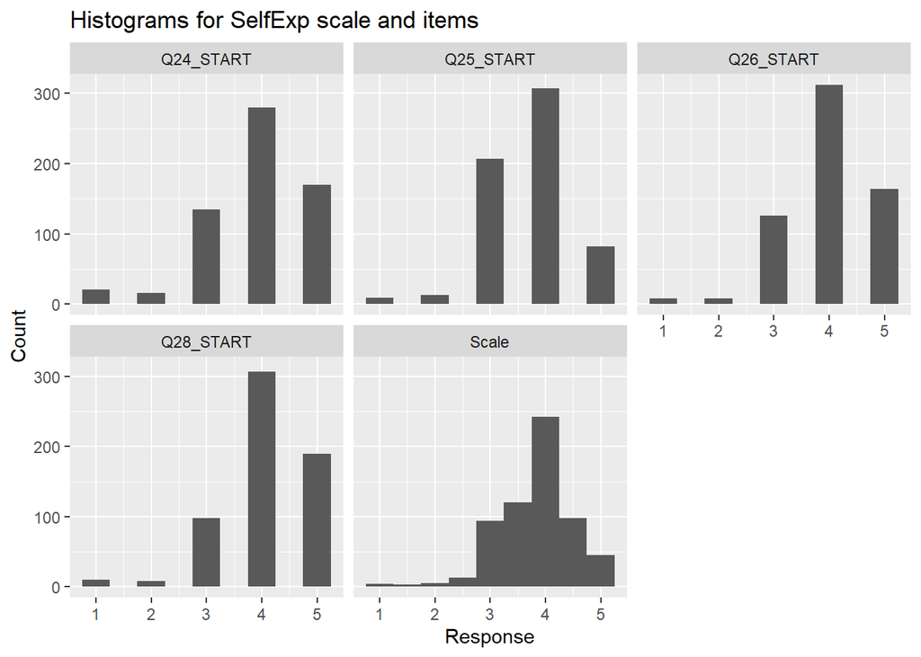

## Rename variables:

**Source**

```r
#Q7.1-START Diverse teams better
#Q7.1-END   Diverse teams better
#Q9.1-START Prefer diverse teams
#Q9.1-END   Prefer diverse teams
#Q47.1-END  Discuss commonalities
#Q47.2-END  Discuss differences

AllDataBoth %<>% rename(
div_better_START = Q7.1_START,
div_better_END = Q7.1_END,
div_prefer_START = Q9.1_START,
div_prefer_END = Q9.1_END   ,
discuss_commonalities = Q47.1_END,
discuss_differences = Q47.2_END)

AllDataBoth$pref_change <- AllDataBoth$div_prefer_END - AllDataBoth$div_prefer_START

AllDataBoth$better_change <- AllDataBoth$div_better_END - AllDataBoth$div_better_START
```

## Calculate descriptives:

**Source**

```r
var_names <- c(
  "div_better_START" = "Diversity value *Start*",
  "div_better_END" = "Diversity value *End*",
  "div_prefer_START" = "Diversity preference *Start*",
  "div_prefer_END" = "Diversity preference *End*",
  "discuss_differences" = "Discussed differences",
  "selfexpor" = "Self-expansion orientation")

cor_table <- AllDataBoth %>%
  cor_matrix(var_names, method = "spearman") %>%
  report_cor_table(add_distributions = TRUE, data = AllDataBoth)

cor_table
```

Variable

*M (SD)*

Distributions

1

2

3

4

5

1. Diversity value *Start*

3.63 (0.94)

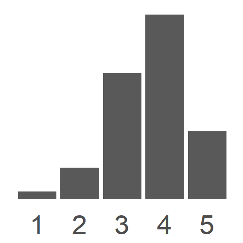

2. Diversity value *End*

3.63 (0.89)

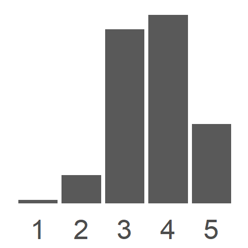

.33 ***  
[0.25, 0.40]

3. Diversity preference *Start*

3.52 (1.02)

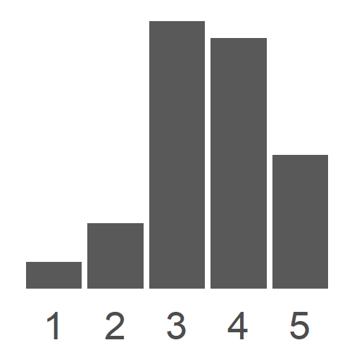

.31 ***  
[0.23, 0.37]

.24 ***  
[0.16, 0.32]

4. Diversity preference *End*

3.79 (0.98)

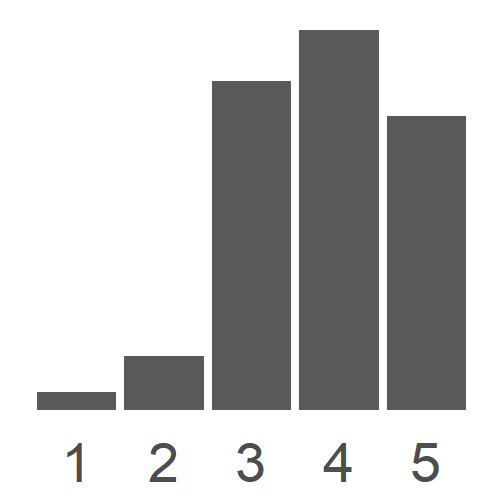

.21 ***  
[0.13, 0.28]

.50 ***  
[0.43, 0.55]

.21 ***  
[0.13, 0.29]

5. Discussed differences

3.60 (0.92)

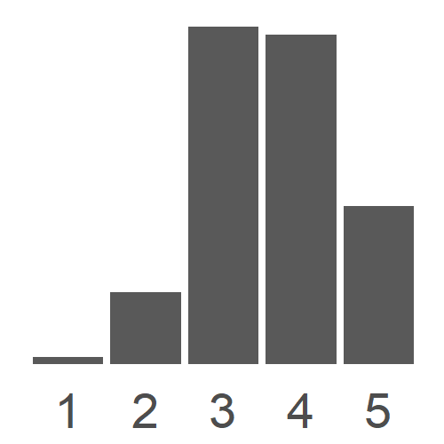

.10 *  
[0.02, 0.18]

.23 ***  
[0.15, 0.30]

.06  
[-0.02, 0.14]

.17 ***  
[0.09, 0.25]

6. Self-expansion orientation

3.92 (0.66)

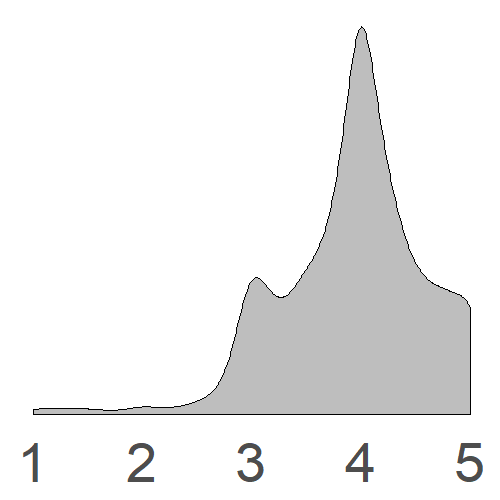

.24 ***  
[0.16, 0.31]

.13 **  
[0.04, 0.21]

.21 ***  
[0.13, 0.28]

.14 ***  
[0.06, 0.23]

.15 ***  
[0.07, 0.24]

*M* and *SD* are used to represent mean and standard deviation, respectively. Values in square brackets indicate the 95% confidence interval for each correlation.

† *p* < .1, * *p* < .05, ** *p* < .01, *** *p* < .001

**Source**

```r
cor_table %>% gt::gtsave("cor_table_hists.html")
```

# H1 + 2: Valuing diversity

… increases during the programme?

**Source**

```r
AllDataBoth$ID <- factor(AllDataBoth$`NCS ID`)
AllDataBoth$WaveID %<>% factor()


#Prefer diverse teams

AllDataBoth_gathered <- AllDataBoth %>%
  gather("time", "div_prefer", c(div_prefer_START, div_prefer_END)) %>%
  mutate(time = factor(time) %>% relevel(ref = "div_prefer_START"), div_prefer = factor(div_prefer, ordered = TRUE), discuss_commonalities = factor(discuss_commonalities, ordered = TRUE), discuss_differences = factor(discuss_differences, ordered = TRUE))

mod1 <- clmm(div_prefer ~ time + (1 | ID) + (1 | WaveID), data = AllDataBoth_gathered)
summary(mod1)
```

**Output**

```
## Cumulative Link Mixed Model fitted with the Laplace approximation
##
## formula: div_prefer ~ time + (1 | ID) + (1 | WaveID)
## data:    AllDataBoth_gathered
##
##  link  threshold nobs logLik   AIC     niter     max.grad cond.H
##  logit flexible  1265 -1711.91 3437.81 347(1044) 1.75e-03 2.3e+01
##
## Random effects:
##  Groups Name        Variance Std.Dev.
##  ID     (Intercept) 0.5843   0.7644
##  WaveID (Intercept) 0.1538   0.3922
## Number of groups:  ID 693,  WaveID 178
##
## Coefficients:
##                    Estimate Std. Error z value Pr(>|z|)
## timediv_prefer_END   0.5432     0.1074   5.055 4.29e-07 ***
## ---
## Signif. codes:  0 '***' 0.001 '**' 0.01 '*' 0.05 '.' 0.1 ' ' 1
##
## Threshold coefficients:
##     Estimate Std. Error z value
## 1|2 -3.49255    0.19052 -18.332
## 2|3 -2.15598    0.13009 -16.573
## 3|4 -0.03192    0.09212  -0.347
## 4|5  1.73052    0.11723  14.762
## (145 observations deleted due to missingness)
```

**Source**

```r
(AllDataBoth$div_prefer_END - AllDataBoth$div_prefer_START) %>%
  sign() %>%
  table() %>%
  prop.table() %>%
  fmt_pct()
```

**Output**

```
## .
##    -1     0     1
## 21.3% 42.0% 36.7%
```

**Source**

```r
#Diverse teams better (instrumental)

AllDataBoth_gathered <- AllDataBoth %>%
  gather("time", "div_better", c(div_better_START, div_better_END)) %>%
  mutate(time = factor(time) %>% relevel(ref = "div_better_START"), div_better = factor(div_better, ordered = TRUE), discuss_commonalities = factor(discuss_commonalities, ordered = TRUE), discuss_differences = factor(discuss_differences, ordered = TRUE))

mod1 <- clmm(div_better ~ time + (1 | ID) + (1 | WaveID), data = AllDataBoth_gathered)
summary(mod1)
```

**Output**

```
## Cumulative Link Mixed Model fitted with the Laplace approximation
##
## formula: div_better ~ time + (1 | ID) + (1 | WaveID)
## data:    AllDataBoth_gathered
##
##  link  threshold nobs logLik   AIC     niter     max.grad cond.H
##  logit flexible  1277 -1636.16 3286.32 461(1396) 1.81e-03 2.5e+01
##
## Random effects:
##  Groups Name        Variance Std.Dev.
##  ID     (Intercept) 1.584    1.258
##  WaveID (Intercept) 0.000    0.000
## Number of groups:  ID 699,  WaveID 178
##
## Coefficients:
##                    Estimate Std. Error z value Pr(>|z|)
## timediv_better_END -0.06984    0.10998  -0.635    0.525
##
## Threshold coefficients:
##     Estimate Std. Error z value
## 1|2 -4.58868    0.24575 -18.672
## 2|3 -2.85792    0.15601 -18.318
## 3|4 -0.44286    0.09773  -4.532
## 4|5  2.05926    0.13070  15.756
## (133 observations deleted due to missingness)
```

**Source**

```r
(AllDataBoth$div_better_END - AllDataBoth$div_better_START) %>%
  sign() %>%
  table() %>%
  prop.table() %>%
  fmt_pct()
```

**Output**

```
## .
##    -1     0     1
## 30.4% 43.9% 25.6%
```

# Permutation tests of main effects

**Source**

```r
# Regression to the mean
wilcox.test(AllDataBoth$div_prefer_START, y = AllDataBoth$div_prefer_END - AllDataBoth$div_prefer_START)
```

**Output**

```
##
##  Wilcoxon rank sum test with continuity correction
##
## data:  AllDataBoth$div_prefer_START and AllDataBoth$div_prefer_END - AllDataBoth$div_prefer_START
## W = 361588, p-value < 2.2e-16
## alternative hypothesis: true location shift is not equal to 0
```

**Source**

```r
wilcox.test(AllDataBoth$div_better_START, y = AllDataBoth$div_better_END - AllDataBoth$div_better_START)
```

**Output**

```
##
##  Wilcoxon rank sum test with continuity correction
##
## data:  AllDataBoth$div_better_START and AllDataBoth$div_better_END - AllDataBoth$div_better_START
## W = 388661, p-value < 2.2e-16
## alternative hypothesis: true location shift is not equal to 0
```

## Instrumental value

**Source**

```r
# Permutation of both variables - calculate expected score in each
better <- AllDataBoth %>%
  select(div_better_START, div_better_END) %>%
  drop_na()

obs_changes_better <- better %>%
  group_by(div_better_START) %>%
  summarise(M = mean(div_better_END)) %>%
  tidyr::pivot_wider(names_from = div_better_START, values_from = M)

no_perm <- 5000
pb <- txtProgressBar(
  min = 0, max = no_perm, initial = 0, char = "=",
  width = NA, title, label, style = 1, file = ""
)
set.seed(300688)
perm_better <- map_dfr(1:no_perm, function(x) {
  ind <- sample(c(TRUE, FALSE), nrow(better), replace = TRUE)
  out <- better %>%
    mutate(pre = ifelse(ind, div_better_START, div_better_END), post = ifelse(!ind, div_better_START, div_better_END)) %>%
    group_by(pre) %>%
    summarise(M = mean(post), .groups = "drop") %>%
    tidyr::pivot_wider(names_from = pre, values_from = M)

  setTxtProgressBar(pb, x, title = NULL, label = NULL)
  out
})
```

**Output**

**Source**

```r
close(pb)
```

**Source**

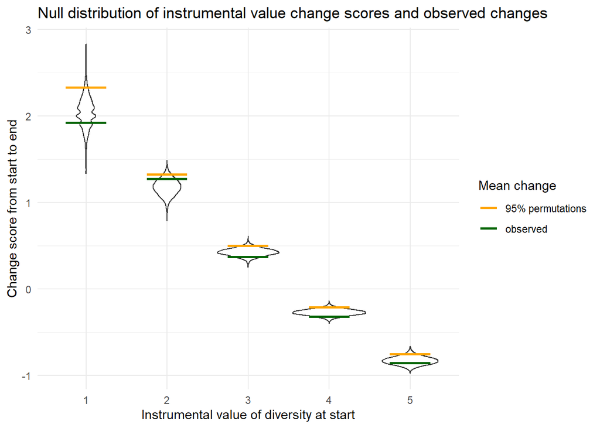

```r
obs_changes_better %<>% tidyr::pivot_longer(everything()) %>% mutate(change = value - as.numeric(name))

res_better <- map2_dfr(obs_changes_better$value, perm_better, function(obs, perm) {
  tibble(sig = mean(obs[1] < perm), M = obs)
}) %>% mutate(pre = 1:5)

n_better <- better %>%
  group_by(div_better_START) %>%
  summarise(n = n())



cut_offs_better <- perm_better %>%
  tidyr::pivot_longer(everything()) %>%
  mutate(change = value - as.numeric(name)) %>%
  group_by(name) %>%
  summarise(change = quantile(change, .95))

perm_better %>%
  tidyr::pivot_longer(everything()) %>%
  mutate(change = value - as.numeric(name)) %>%
  ggplot(aes(x = name, y = change)) +
  geom_violin() +
  stat_summary_bin(
    data = obs_changes_better, fun = mean, fun.min = mean, fun.max = mean, mapping = aes(group = name, color = "observed"),
    geom = "hpline",
    width = .5, size = 1
  ) +
  stat_summary_bin(
    data = cut_offs_better, fun = mean, fun.min = mean, fun.max = mean,
    geom = "hpline", mapping = aes(group = name, color = "95% permutations"),
    width = .5, size = 1
  ) +
  labs(title = "Null distribution of instrumental value change scores and observed changes", x = "Instrumental value of diversity at start", y = "Change score from start to end", colour = "Mean change") +
  theme_minimal() +
  scale_color_manual(values = c("orange", "darkgreen"))
```

**Source**

```r
#timesaveR::ggsave_show(width = 20, height = 10)

#Could add formal significance testing based on chi-squared goodness of fit? Probably not needed.
```

**Source**

```r
#Permutation of preference
prefer <- AllDataBoth %>%
  select(div_prefer_START, div_prefer_END) %>%
  drop_na()

obs_changes_prefer <- prefer %>%
  group_by(div_prefer_START) %>%
  summarise(M = mean(div_prefer_END)) %>%
  tidyr::pivot_wider(names_from = div_prefer_START, values_from = M)

pb <- txtProgressBar(
  min = 0, max = no_perm, initial = 0, char = "=",
  width = NA, title, label, style = 1, file = ""
)
set.seed(300688)
perm_prefer <- map_dfr(1:no_perm, function(x) {
  ind <- sample(c(TRUE, FALSE), nrow(prefer), replace = TRUE)
  out <- prefer %>%
    mutate(pre = ifelse(ind, div_prefer_START, div_prefer_END), post = ifelse(!ind, div_prefer_START, div_prefer_END)) %>%
    group_by(pre) %>%
    summarise(M = mean(post), .groups = "drop") %>%
    tidyr::pivot_wider(names_from = pre, values_from = M)
  setTxtProgressBar(pb, x, title = NULL, label = NULL)
  out
})
```

**Output**

**Source**

```r
close(pb)
```

**Source**

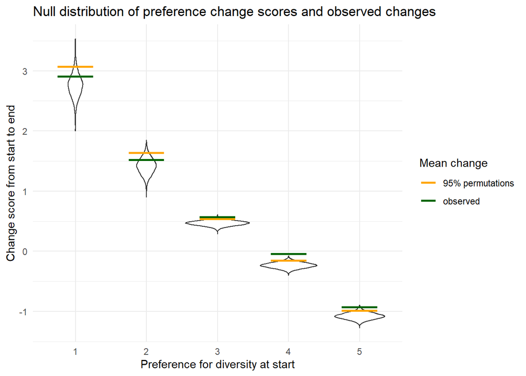

```r
obs_changes_prefer %<>% tidyr::pivot_longer(everything()) %>% mutate(change = value - as.numeric(name))

res_prefer <- map2_dfr(obs_changes_prefer$value, perm_prefer, function(obs, perm) {
  tibble(sig = mean(obs[1] < perm), M = obs)
}) %>% mutate(pre = 1:5)

n_prefer <- prefer %>%
  group_by(div_prefer_START) %>%
  summarise(n = n())

cut_offs <- perm_prefer %>%
  tidyr::pivot_longer(everything()) %>%
  mutate(change = value - as.numeric(name)) %>%
  group_by(name) %>%
  summarise(change = quantile(change, .95))

perm_prefer %>%
  tidyr::pivot_longer(everything()) %>%
  mutate(change = value - as.numeric(name)) %>%
  ggplot(aes(x = name, y = change)) +
  geom_violin() +
  stat_summary_bin(
    data = obs_changes_prefer, fun = mean, fun.min = mean, fun.max = mean, mapping = aes(group = name, color = "observed"),
    geom = "hpline",
    width = .5, size = 1
  ) +
  stat_summary_bin(
    data = cut_offs, fun = mean, fun.min = mean, fun.max = mean,
    geom = "hpline", mapping = aes(group = name, color = "95% permutations"),
    width = .5, size = 1
  ) +
  labs(title = "Null distribution of preference change scores and observed changes", x = "Preference for diversity at start", y = "Change score from start to end", colour = "Mean change") +
  theme_minimal() +
  scale_color_manual(values = c("orange", "darkgreen"))
```

**Source**

```r
#ggsave_show(width = 20, height = 10)
```

# H3 - interaction with talking about differences

**Source**

```r
AllDataBoth_fact <- AllDataBoth %>%
  dplyr::select(WaveID, div_prefer_START, div_prefer_END, div_better_START, div_better_END, discuss_differences, selfexpor, pref_change, better_change, Ethn_type) %>%
  mutate(across(c(everything(), -selfexpor, -Ethn_type), factor, ordered = TRUE))


mod1 <- clmm(div_prefer_END ~ div_prefer_START + discuss_differences + (1 | WaveID), data = AllDataBoth_fact)
```

**Warning**

```
## Warning: Using formula(x) is deprecated when x is a character vector of length > 1.
##   Consider formula(paste(x, collapse = " ")) instead.
```

**Source**

```r
mod0 <- clmm(div_prefer_END ~ div_prefer_START + (1 | WaveID), data = AllDataBoth_fact %>% drop_na(discuss_differences))
anova(mod0, mod1, type = 2)
```

**Output**

```
## Likelihood ratio tests of cumulative link models:
##
##      formula:
## mod0 div_prefer_END ~ div_prefer_START + (1 | WaveID)
## mod1 div_prefer_END ~ div_prefer_START + discuss_differences + (1 | WaveID)
##      link: threshold:
## mod0 logit flexible
## mod1 logit flexible
##
##      no.par    AIC  logLik LR.stat df Pr(>Chisq)
## mod0      9 1399.5 -690.74
## mod1     13 1388.5 -681.27  18.924  4  0.0008136 ***
## ---
## Signif. codes:  0 '***' 0.001 '**' 0.01 '*' 0.05 '.' 0.1 ' ' 1
```

**Source**

```r
prefer <- emmeans::emmip(mod1, ~discuss_differences, mode = "mean.class", plotit = F) %>% mutate(measure = "prefer")

mod2 <- clmm(div_better_END ~ div_better_START + discuss_differences + (1 | WaveID), data = AllDataBoth_fact)
```

**Warning**

```
## Warning: Using formula(x) is deprecated when x is a character vector of length > 1.
##   Consider formula(paste(x, collapse = " ")) instead.
```

**Source**

```r
summary(mod2)
```

**Output**

```
## Cumulative Link Mixed Model fitted with the Laplace approximation
##
## formula: div_better_END ~ div_better_START + discuss_differences + (1 |
##     WaveID)
## data:    AllDataBoth_fact
##
##  link  threshold nobs logLik  AIC     niter      max.grad cond.H
##  logit flexible  548  -656.35 1338.69 1058(2133) 4.50e-04 7.7e+02
##
## Random effects:
##  Groups Name        Variance Std.Dev.
##  WaveID (Intercept) 0.02492  0.1579
## Number of groups:  WaveID 154
##
## Coefficients:
##                       Estimate Std. Error z value Pr(>|z|)
## div_better_START.L      1.9455     0.4019   4.840  1.3e-06 ***
## div_better_START.Q      0.2826     0.3417   0.827  0.40815
## div_better_START.C      0.2859     0.2777   1.029  0.30327
## div_better_START^4     -0.1342     0.2013  -0.667  0.50496
## discuss_differences.L   1.2248     0.4530   2.704  0.00685 **
## discuss_differences.Q   0.1115     0.3868   0.288  0.77311
## discuss_differences.C   0.2647     0.2928   0.904  0.36608
## discuss_differences^4  -0.2307     0.1931  -1.195  0.23228
## ---
## Signif. codes:  0 '***' 0.001 '**' 0.01 '*' 0.05 '.' 0.1 ' ' 1
##
## Threshold coefficients:
##     Estimate Std. Error z value
## 1|2  -3.9328     0.3714 -10.588
## 2|3  -2.2404     0.2256  -9.930
## 3|4   0.2117     0.1937   1.093
## 4|5   2.2399     0.2166  10.342
## (157 observations deleted due to missingness)
```

**Source**

```r
mod0 <- clmm(div_better_END ~ div_better_START + (1 | WaveID), data = AllDataBoth_fact %>% drop_na(discuss_differences))

anova(mod0, mod2, type = 2)
```

**Output**

```
## Likelihood ratio tests of cumulative link models:
##
##      formula:
## mod0 div_better_END ~ div_better_START + (1 | WaveID)
## mod2 div_better_END ~ div_better_START + discuss_differences + (1 | WaveID)
##      link: threshold:
## mod0 logit flexible
## mod2 logit flexible
##
##      no.par    AIC  logLik LR.stat df Pr(>Chisq)
## mod0      9 1356.2 -669.12
## mod2     13 1338.7 -656.35  25.547  4  3.906e-05 ***
## ---
## Signif. codes:  0 '***' 0.001 '**' 0.01 '*' 0.05 '.' 0.1 ' ' 1
```

**Source**

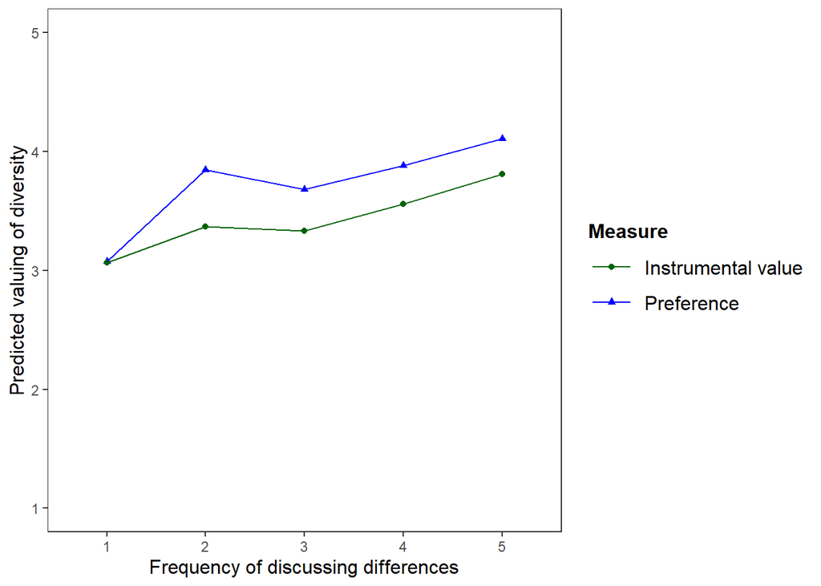

```r
better <- emmeans::emmip(mod2, ~discuss_differences, mode = "mean.class", plotit = FALSE) %>% mutate(measure = "better")

ggplot(mapping = aes(x = discuss_differences, y = yvar, color = measure, shape = measure)) +
  geom_point(data = prefer) +
  geom_point(data = better) +
  geom_line(data = prefer, group = 1) +
  geom_line(data = better, group = 1) +
  jtools::theme_apa(legend.use.title = TRUE) +
  labs(x = "Frequency of discussing differences", y = "Predicted valuing of diversity", color = "Measure") +
  ylim(c(1, 5)) +
  scale_color_manual(values = c("darkgreen", "blue"), labels = c("Instrumental value", "Preference"), name = "Measure") +
  scale_shape_manual(values = c(16, 17), labels = c("Instrumental value", "Preference"), name = "Measure")
```

**Source**

```r
# ggsave_show(width = 20, height = 12)
```

# H4 - interaction with self-expansion orientation

**Source**

```r
mod1 <- clmm(div_prefer_END ~ div_prefer_START + selfexpor + (1|WaveID), data = AllDataBoth_fact)
mod0 <- clmm(div_prefer_END ~ div_prefer_START + (1 | WaveID), data = AllDataBoth_fact %>% drop_na(selfexpor))

summary(mod1)
```

**Output**

```
## Cumulative Link Mixed Model fitted with the Laplace approximation
##
## formula: div_prefer_END ~ div_prefer_START + selfexpor + (1 | WaveID)
## data:    AllDataBoth_fact
##
##  link  threshold nobs logLik  AIC     niter     max.grad cond.H
##  logit flexible  523  -666.06 1352.11 602(1322) 1.79e-05 2.3e+03
##
## Random effects:
##  Groups Name        Variance Std.Dev.
##  WaveID (Intercept) 0.267    0.5167
## Number of groups:  WaveID 151
##
## Coefficients:
##                    Estimate Std. Error z value Pr(>|z|)
## div_prefer_START.L  0.27462    0.33229   0.826  0.40856
## div_prefer_START.Q  0.83596    0.29486   2.835  0.00458 **
## div_prefer_START.C -0.35849    0.26128  -1.372  0.17004
## div_prefer_START^4 -0.06083    0.19507  -0.312  0.75517
## selfexpor           0.27506    0.13656   2.014  0.04399 *
## ---
## Signif. codes:  0 '***' 0.001 '**' 0.01 '*' 0.05 '.' 0.1 ' ' 1
##
## Threshold coefficients:
##     Estimate Std. Error z value
## 1|2  -3.0627     0.6141  -4.987
## 2|3  -1.8553     0.5613  -3.305
## 3|4   0.3955     0.5492   0.720
## 4|5   2.0658     0.5629   3.670
## (182 observations deleted due to missingness)
```

**Source**

```r
anova(mod0, mod1, type = 2)
```

**Output**

```
## Likelihood ratio tests of cumulative link models:
##
##      formula:                                                     link:
## mod0 div_prefer_END ~ div_prefer_START + (1 | WaveID)             logit
## mod1 div_prefer_END ~ div_prefer_START + selfexpor + (1 | WaveID) logit
##      threshold:
## mod0 flexible
## mod1 flexible
##
##      no.par    AIC  logLik LR.stat df Pr(>Chisq)
## mod0      9 1354.2 -668.12
## mod1     10 1352.1 -666.06  4.1287  1    0.04216 *
## ---
## Signif. codes:  0 '***' 0.001 '**' 0.01 '*' 0.05 '.' 0.1 ' ' 1
```

**Source**

```r
mod2 <- clmm(div_better_END ~ div_better_START + selfexpor + (1 | WaveID), data = AllDataBoth_fact)
mod0 <- clmm(div_better_END ~ div_better_START + (1 | WaveID), data = AllDataBoth_fact %>% drop_na(selfexpor))

anova(mod0, mod2, type = 2)
```

**Output**

```
## Likelihood ratio tests of cumulative link models:
##
##      formula:                                                     link:
## mod0 div_better_END ~ div_better_START + (1 | WaveID)             logit
## mod2 div_better_END ~ div_better_START + selfexpor + (1 | WaveID) logit
##      threshold:
## mod0 flexible
## mod2 flexible
##
##      no.par    AIC  logLik LR.stat df Pr(>Chisq)
## mod0      9 1318.7 -650.36
## mod2     10 1319.4 -649.70  1.3337  1     0.2481
```

**Source**

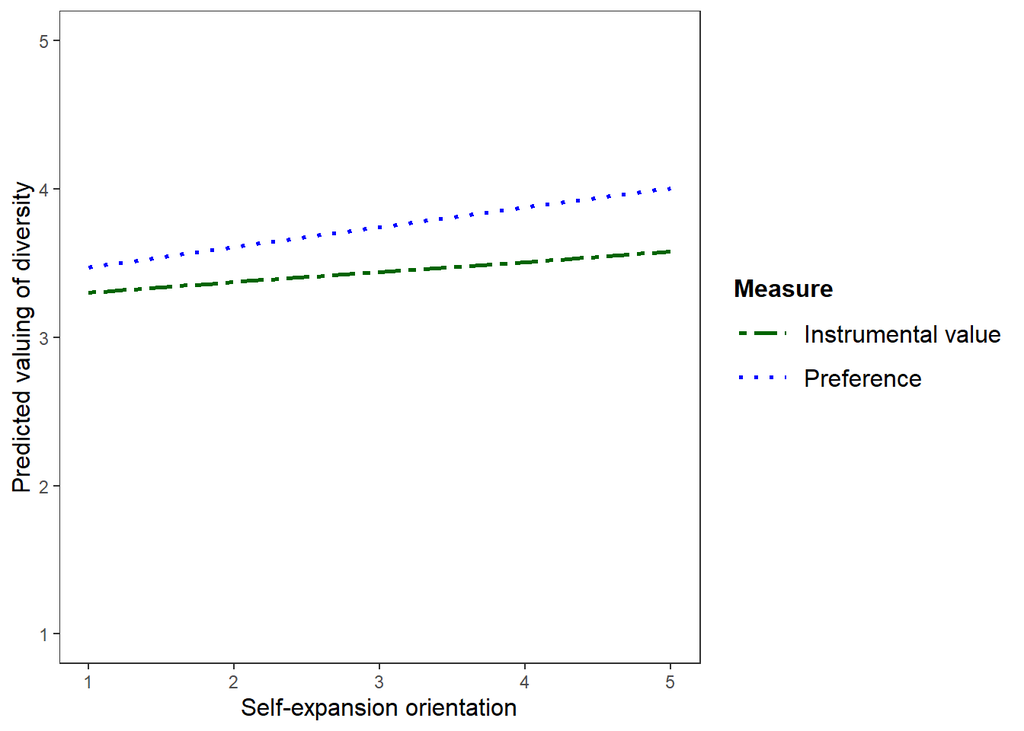

```r
prefer <- emmeans::emmip(mod1, ~selfexpor, at = list(selfexpor = c(1:5)), mode = "mean.class", plotit = FALSE) %>% mutate(measure = "prefer")

better <- emmeans::emmip(mod2, ~selfexpor, at = list(selfexpor = c(1:5)), mode = "mean.class", plotit = FALSE) %>% mutate(measure = "better")

ggplot(mapping = aes(x = selfexpor, y = yvar, color = measure, linetype = measure)) +
  geom_line(data = prefer, group = 1, size = 1) +
  geom_line(data = better, group = 1, size = 1) +
  jtools::theme_apa(legend.use.title = TRUE) +
  labs(x = "Self-expansion orientation", y = "Predicted valuing of diversity", color = "Measure") +
  ylim(c(1, 5)) +
  scale_color_manual(values = c("darkgreen", "blue"), labels = c("Instrumental value", "Preference"), name = "Measure") +
  scale_linetype_manual(values = c("twodash", "dotted"), labels = c("Instrumental value", "Preference"), name = "Measure")
```

**Source**

```r
#ggsave_show(width = 20, height = 12)
```

# Exploratory

**Source**

```r
#Collapse into White & ME (results do not change when mixed-ethnicity are dropped)

AllDataBoth_fact_flt <- AllDataBoth_fact %>%
  mutate(Ethn_type_bin = forcats::fct_collapse(Ethn_type, "White" = "White", other_level = "ME")) %>%
  filter(!is.na(Ethn_type_bin))

mod0 <- clmm(div_prefer_END ~ div_prefer_START + (1 | WaveID), data = AllDataBoth_fact_flt)

mod1 <- clmm(div_prefer_END ~ div_prefer_START + Ethn_type_bin + (1 | WaveID), data = AllDataBoth_fact_flt)

anova(mod0, mod1)
```

**Output**

```
## Likelihood ratio tests of cumulative link models:
##
##      formula:                                                         link:
## mod0 div_prefer_END ~ div_prefer_START + (1 | WaveID)                 logit
## mod1 div_prefer_END ~ div_prefer_START + Ethn_type_bin + (1 | WaveID) logit
##      threshold:
## mod0 flexible
## mod1 flexible
##
##      no.par    AIC  logLik LR.stat df Pr(>Chisq)
## mod0      9 913.02 -447.51
## mod1     10 914.44 -447.22  0.5793  1     0.4466
```

**Source**

```r
mod0 <- clmm(div_better_END ~ div_better_START + (1 | WaveID), data = AllDataBoth_fact_flt)

mod1 <- clmm(div_better_END ~ div_better_START + Ethn_type_bin + (1 | WaveID), data = AllDataBoth_fact_flt)

anova(mod0, mod1)
```

**Output**

```
## Likelihood ratio tests of cumulative link models:
##
##      formula:                                                         link:
## mod0 div_better_END ~ div_better_START + (1 | WaveID)                 logit
## mod1 div_better_END ~ div_better_START + Ethn_type_bin + (1 | WaveID) logit
##      threshold:
## mod0 flexible
## mod1 flexible
##
##      no.par    AIC  logLik LR.stat df Pr(>Chisq)
## mod0      9 896.12 -439.06
## mod1     10 898.11 -439.05  0.0136  1      0.907
```

**Source**

```r
t.test(as.numeric(div_better_START) ~ Ethn_type_bin, AllDataBoth_fact_flt) %>%
  papaja::apa_print() %>%
  extract("full_result") %>%
  stringr::str_replace_all("\\\\|\\$", "") %>%
  stringr::str_replace_all("Delta", "<U+0394>")
```

**Output**

```
## [1] "Δ M = -0.13, 95% CI [-0.34, 0.07], t(241.54) = -1.26, p = .208"
```

**Source**

```r
t.test(as.numeric(div_prefer_START) ~ Ethn_type_bin, AllDataBoth_fact_flt) %>%
  papaja::apa_print() %>%
  extract("full_result") %>%
  stringr::str_replace_all("\\\\|\\$", "") %>%
  stringr::str_replace_all("Delta", "<U+0394>")
```

**Output**

```
## [1] "Δ M = -0.04, 95% CI [-0.25, 0.18], t(269.76) = -0.33, p = .741"
```